# Session 06 Artificial Neural Networks

[**CCMVI2085U Machine Learning for Predictive Analytics in Business @ CBS ISUP 2020**](https://kursuskatalog.cbs.dk/2019-2020/KAN-CCMVI2085U.aspx?lang=en-GB)

Course coordinator: [Bowei Chen](https://boweichen.github.io/) | Email: bc.acc@cbs.dk

Artificial neural networks (in short neural networks or ANNs) have a range of real-world applications in the business domain, ranging from customer credit scoring, to bankruptcy prediction, stock and commodity selection and trading, sales forecasting, new product design and target marketing. This session aims to give you a brief introduction to ANNs and the implementation of a simple ANN model in Python for solving classification and regression problems.

# Table of Contents

## Motivating example

[figure not shown]

Suppose we are business analysts working with a client – a large seaside resort company whose business is to provide affordable holiday family fun activities and entertainments. The company would like us to develop a model which can recommend this summer’s events to the booked customers (i.e., booked flats). Our goal is to develop a data-driven model which can segment customers from the last summer’s data and use it to recommend events to this summer’s new bookings.

As the response variable contains three different values of summer’s events (i.e., spa, shows, and outdoor activities), this is a multi-class classification problem. There are a number of classification algorithms can be used here. In this session, we are going to develop a simple ANN to segment consumers.

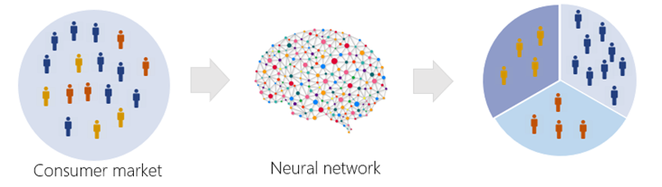

## Data loading and initial check

The first step is to load the dataset, and see an overall picture of data using descriptive analytics. In Python, we can use `pandas` library to load the dataset into Jupyter notebook and check variables and dimension of the data.

```
import pandas as pd

df = pd.read_csv("data/Holiday_Rental_Consumer_Segmentation.csv")

print(df.head())
print(df.shape)
```

```
   Price   Size  Bedroom  Bathroom  Floor Car_Parking Internet Location Pet  \
0  420.0  292.5        3         1      2         Yes       No   Area_2  No
1  660.0  208.0        3         1      1         Yes       No   Area_1  No
2  660.0  194.0        3         2      2         Yes       No   Area_3  No
3  838.0  240.0        3         1      1         Yes       No   Area_1  No
4  900.0  360.0        3         2      1         Yes       No   Area_4  No

  Event
0   Spa
1   Spa
2   Spa
3   Spa
4   Spa
(191, 10)
```

We can also use `df.info()` to show a bit summarised information of the data frame/table.

```
<class 'pandas.core.frame.DataFrame'>
RangeIndex: 191 entries, 0 to 190
Data columns (total 10 columns):
 #   Column       Non-Null Count  Dtype
---  ------       --------------  -----
 0   Price        191 non-null    float64
 1   Size         191 non-null    float64
 2   Bedroom      191 non-null    int64
 3   Bathroom     191 non-null    int64
 4   Floor        191 non-null    int64
 5   Car_Parking  191 non-null    object
 6   Internet     191 non-null    object
 7   Location     191 non-null    object
 8   Pet          191 non-null    object
 9   Event        191 non-null    object
dtypes: float64(2), int64(3), object(5)
memory usage: 15.0+ KB
```

Let's further check the types and values of the variables in the dataset

```
for col, col_dtype in zip(df.columns, df.dtypes):
    print(
        "====\n Variable: {0:} \n Data type: {1:} \n Unique values: {2:} \n".format(
            col, col_dtype, df[col].unique()
        )
    )
```

```
====
 Variable: Price
 Data type: float64
 Unique values: [ 420.   660.   838.   900.   450.   485.   659.   440.   617.   545.
  665.   700.   570.   680.   950.   560.   600.   670.   510.   325.
  350.   470.   550.   639.   555.   780.   580.  1630.  1235.   599.
  790.  1250.   730.   635.   750.   945.  1065.  1160.  1170.   400.
  572.5  610.   800.   370.   620.  1300.   529.   480.   525.   500.
  699.   447.   575.   520.   539.   695.   720.   925.  1383.   785.
  708.   260.   645.   710.   462.   630.   649.   745.   650.   769.
  990.  1240.  1060.  1550.  1410.   595.   685.   860.  1750.  1200.
  820.   850.  1220.   840.   970.  1125.  1400.   747.   789.   869.
  770.   807.5  829.   760.   775.   870.   875.   890.  1000.   917.
 1745.   611.   585.5 1049.   749.   795.  1209.   476.   490.   605.
  930.   885.   880.   895.   955.   590.   715.   719.   589. ]

====
 Variable: Size
 Data type: float64
 Unique values: [292.5  208.   194.   240.   360.   199.3  239.25 225.5  248.   175.
 201.6  157.5  187.25 226.   108.   205.   458.3  202.   363.   275.
 252.   300.   204.75  91.8  160.5   82.5  159.   318.   189.   154.5
 303.   295.   371.   402.5  412.5  225.   165.   216.   150.   187.5
 213.   200.   215.   342.   206.   298.   228.   132.5  108.75 180.
 147.65  95.25 156.   203.75 155.   181.5  151.8  171.   274.75 173.
 178.5  126.   217.5  177.   198.   140.85 140.   190.8  159.25 316.05
 235.   238.5  198.5  172.5  176.   220.5  182.   245.   127.5  483.35
 290.   249.75 322.5  444.   357.75 372.   375.   405.   202.3  350.
 340.   330.   498.   535.   660.   397.5  305.   321.   327.   358.
 327.5  354.25 345.   351.   400.   481.   525.   335.5  333.   361.55
 370.5  390.   341.25 450.   142.5  320.   558.75 337.5  256.8  170.
 143.5  266.   420.   202.5  572.   302.5  190.   270.   107.25 130.5
  97.5  100.75 139.35 249.5  333.5  312.7  272.5  285.   299.25 407.5
 232.3  250.5  384.3 ]

====
 Variable: Bedroom
 Data type: int64
 Unique values: [3 2 4 5]

```

[output cut: 19 more lines]

```

====
 Variable: Location
 Data type: object
 Unique values: ['Area_2' 'Area_1' 'Area_3' 'Area_4']

====
 Variable: Pet
 Data type: object
 Unique values: ['No' 'Yes']

====
 Variable: Event
 Data type: object
 Unique values: ['Spa' 'Outdoor activities' 'Shows']
```

## Data preparation

Once we have loaded the data and have performed the initial check with it. Another important stage is to preprocess data for the our target machine learning algorithms, including data encoding, scaling or standardization, and spliting. Here we can simply call this stage **data preparation** or **data preprocessing**

### Data encoding

The term **encoding** means we convert the data values into a specified format or form. Decoding is the reverse process of encoding which is to extract the information from the converted format. In the data preparation stage, data encoding is mainly for feature encoding and/or label encoding. Sometimes, we just simply say feature encoding for both.

We can use `pandas.get_dummies` to encode categorical feature variables. Here we exclude the response variable because it has three categories.

```
df_features = pd.get_dummies(df.iloc[:, :-1], drop_first=True)
df_features.head()
```

|  | Price | Size | Bedroom | Bathroom | Floor | Car_Parking_Yes | Internet_Yes | Location_Area_2 | Location_Area_3 | Location_Area_4 | Pet_Yes |
| --- | --- | --- | --- | --- | --- | --- | --- | --- | --- | --- | --- |
| 0 | 420.0 | 292.5 | 3 | 1 | 2 | 1 | 0 | 1 | 0 | 0 | 0 |
| 1 | 660.0 | 208.0 | 3 | 1 | 1 | 1 | 0 | 0 | 0 | 0 | 0 |
| 2 | 660.0 | 194.0 | 3 | 2 | 2 | 1 | 0 | 0 | 1 | 0 | 0 |
| 3 | 838.0 | 240.0 | 3 | 1 | 1 | 1 | 0 | 0 | 0 | 0 | 0 |
| 4 | 900.0 | 360.0 | 3 | 2 | 1 | 1 | 0 | 0 | 0 | 1 | 0 |

We then convert all the feature variables into an ndarrray

```
x = df_features.to_numpy()
print(x)
```

```
[[420.  292.5   3.  ...   0.    0.    0. ]
 [660.  208.    3.  ...   0.    0.    0. ]
 [660.  194.    3.  ...   1.    0.    0. ]
 ...
 [660.  250.5   3.  ...   0.    0.    0. ]
 [589.  303.    2.  ...   0.    0.    0. ]
 [710.  384.3   3.  ...   0.    0.    0. ]]
```

We then use `LabelEncoder` from `sklearn` to encode the response variable

```
from sklearn import preprocessing

le = preprocessing.LabelEncoder()
le.fit(df["Event"])
print(le.classes_)
y = le.transform(df["Event"])
print(y)
```

```
['Outdoor activities' 'Shows' 'Spa']
[2 2 2 2 2 0 2 2 0 0 2 0 2 1 2 2 2 1 0 2 2 2 1 2 0 2 2 2 0 2 2 2 2 0 0 2 1
 2 2 2 1 1 1 2 1 1 1 1 2 1 1 2 2 2 2 1 2 2 2 1 2 2 2 0 2 1 0 0 2 2 2 2 2 2
 1 1 1 1 0 0 2 1 0 2 2 2 0 0 2 1 2 2 2 2 2 2 2 2 2 2 1 2 2 1 2 2 1 1 1 2 1
 2 1 1 1 2 1 2 2 2 1 2 1 1 1 2 1 2 2 2 2 2 2 2 1 1 1 2 1 2 2 2 2 2 2 1 2 2
 2 2 2 2 1 1 2 2 0 2 1 2 1 1 2 2 1 1 1 2 2 2 2 2 0 2 2 1 2 2 2 1 2 1 2 2 1
 2 2 1 2 0 2]
```

### Scaling and standardization

Machine learning algorithms can work better when features are on a relatively similar scale and close to normally distributed. Scaling and standardization are popular methods to perform transformation on numerical feature variables.

Let $x$ denote the (univariate) variable and its values over the dataset can be indexed by $n = 1, 2, \ldots, N$. Then

- **Min-max** is a popular scaling method, which means the change in the range of the variable values but not in the shape of the distribution. The range is often set between 0 and 1. $$ \widetilde{x}_{n} = \frac{x_n - \text{min}(x)}{\text{max}(x) - \text{min}(x)}. $$ If scaling to a range between $a$ and $b$, then the min-max can be calculated by $$ \widetilde{x}_{n} = a + \frac{(x_n - \text{min}(x))(b-a)}{\text{max}(x)-\text{min}(x)} $$
- **Standardization** (or **z-score nomarlization**) means changing the values so that the output distribution is close to a normal distribution. It should noted that it can behave badly if the individual features do not more or less look like normally distributed data. When we perform standardization, scaling is often implied. $$ \widetilde{x}_{n} = \frac{x_n - \bar{x}}{\text{std}(x)} = \frac{x_n - \bar{x}}{\sqrt{\text{var}(x)}}, $$ where $\text{var}(x)$ is the variance of the sample data.

We can use `MinMaxScaler` and `StandardScaler` to perform min-max and standardization for numerical variables.

[output not shown]

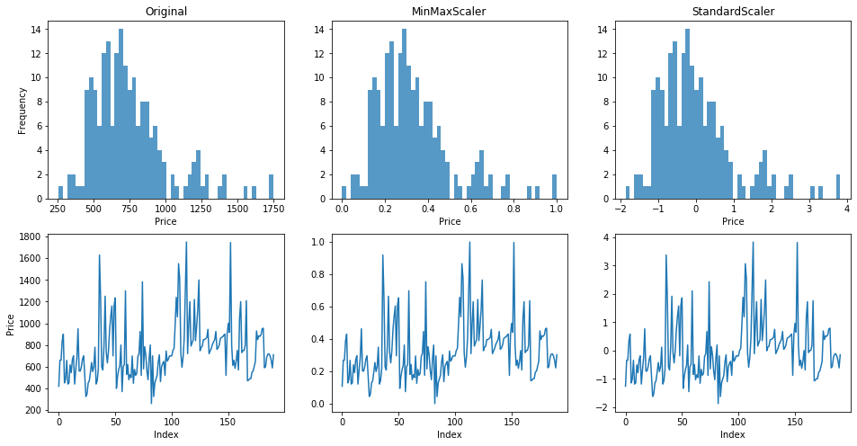

For this consumer segmentation project, let's apply standardization (z-score normalization) to numerical feature variables.

```
min_max = StandardScaler()
min_max.fit(x[:, :5])
x[:, :5] = min_max.transform(x[:, :5])
```

### Training and test data split

[output not shown]

## Artificial neural networks

### What is an artificial neural network?

ANNs are a special tribe of machine learning in which algorithms process signals via interconnected nodes called **neurons**. They mimic the architecture of biological nervous systems so ANN's untimate goal is to model the brain.

### Types of neural network

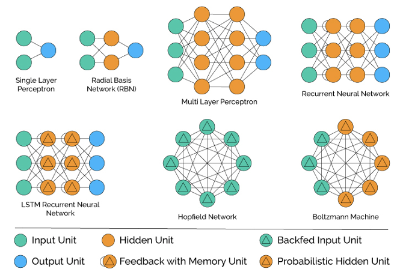

Fig source: https://www.xenonstack.com/blog/artificial-neural-network-applications

### Multi-layer perceptron

As usual, we denote the dataset by notation $\mathcal{D}$, where

$$\mathcal{D} = \{(\boldsymbol{x}_1, y_1), \cdots, (\boldsymbol{x}_N, y_N)\} = \{(\boldsymbol{x}_n, y_n)\}_{n=1}^{N}$$$$ \boldsymbol{X} = \left[ \begin{array}{ccc} x_{11} & \cdots & x_{1D} \\ \vdots & \ddots & \vdots \\ x_{N1} & \cdots & x_{ND} \\ \end{array} \right] = \left[ \begin{array}{c} \boldsymbol{x}_1^\top \\ \vdots\\ \boldsymbol{x}_N^\top \\ \end{array} \right] , \ \ \ \ \ \boldsymbol{y} = \left[ \begin{array}{ccc} y_{1} \\ \vdots \\ y_{N} \\ \end{array} \right]$$

Here we know the response variable $y$ has $K$ classes.

#### How does the MLP work?

The following the a simple architecture or structure of a **multi-layer perceptron (MLP)**. It contains three layers, input layer, hidden layer and output layer. In some references, we also call this **two-layer neural network** (not including the input layer in the counting).

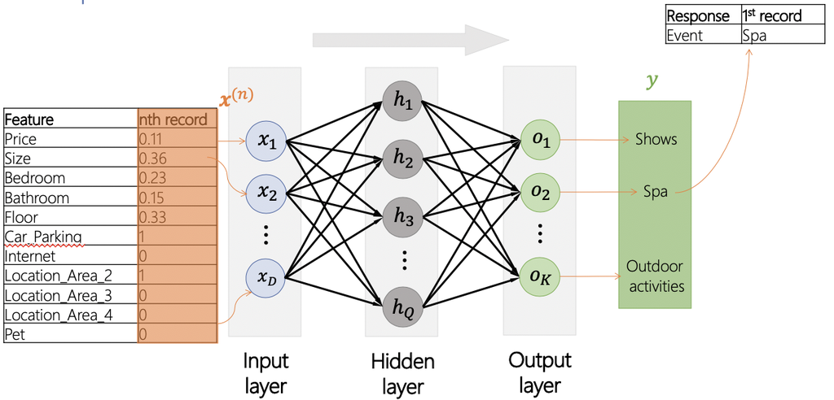

From the input layer to the hidden layer

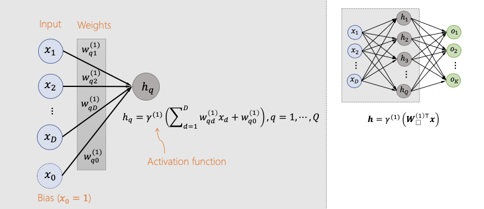

From the hidden layer to the output layer

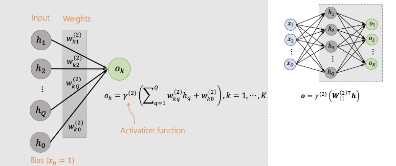

#### Mathematical representation of the neural network

- With bias term

$$ o_k = \gamma^{(2)} \left(\sum_{q=1}^{Q} w_{kq}^{(2)}\gamma^{(1)}\left( \sum_{d=1}^{D} w_{qd}^{(1)}x_d + w_{q0}^{(1)}\right) + w_{k0}^{(2)}\right) $$

- Absorbinng bias term

$$ o_k = \gamma^{(2)} \left(\sum_{q=0}^{Q} w_{kq}^{(2)}\gamma^{(1)}\left( \sum_{d=0}^{D} w_{qd}^{(1)}x_d \right) \right) $$

- Matrix form

$$ \boldsymbol{o} = \gamma^{(2)}(\boldsymbol{W}^{(2) \top} \left[ \gamma^{(1)} \left(\boldsymbol{W}^{(1) \top} \boldsymbol{x}\right)\right]) $$

#### Popular activation functions

- Sigmoid $$\gamma(u) = \frac{1}{1+e^{-u}}$$
- Tanh $$\gamma(u) = \frac{e^{u} - e^{-u}}{e^{u} + e^{-u}}$$
- Rectified linear unit (ReLU) $$\gamma(u) = \max\{0, u\}$$

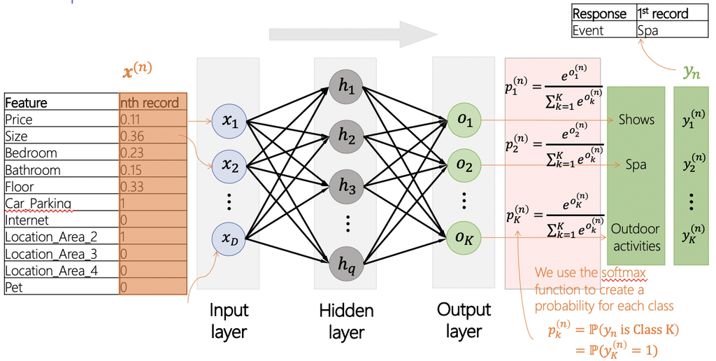

#### Cross-entropy loss function for multi-class classification

The cross-entropy loss function measures the performance of a classification model whose output is a probability value between 0 and 1. For an observation, it is defined as

$$- \sum_{k=1}^K y_k log\{p_k\}$$

where $y_k \in \{0,1\}$ and $p_k$ shows the predicted probability of an observation is of class $k$, $k=1,\ldots, K$.

For $N$ observations, we have

$$ \mathscr{L}(\boldsymbol{W}^{(1)}, \boldsymbol{W}^{(2)}) = - \sum_{n=1}^{N} \sum_{k=1}^{K} y_k^{(n)} \log\{p_k^{(n)}\} = - \sum_{n=1}^{N} \sum_{k=1}^{K} y_k^{(n)} \log\left\{ \frac{e^{o_k^{(n)}}}{\sum_{k=1}^{K} e^{o_k^{(n)}}}\right\}. $$

#### Backpropagation

To solve the above optimization problem, we can use the gradient descent method, which we saw in the previous sessions. However, since a neural network contains a large number of weights, directly calculating partial derivatives of weights from the input layers to the output layers is time consuming. We can use the backpropagation algorithm (BP) together with gradient decent to estimate the weights. I am not going to further discuss this here. Further references about the standard BP can be found in Bishop Chapter 5.3

### Implementing MLP using sklearn in Python

https://scikit-learn.org/stable/modules/generated/sklearn.neural_network.MLPClassifier.html?highlight=mlp#sklearn.neural_network.MLPClassifier

```
from sklearn.neural_network import MLPClassifier

mlp_clf = MLPClassifier(random_state=100, max_iter=10000)
mlp_clf.fit(x_train, y_train)
```

```
MLPClassifier(activation='relu', alpha=0.0001, batch_size='auto', beta_1=0.9,
              beta_2=0.999, early_stopping=False, epsilon=1e-08,
              hidden_layer_sizes=(100,), learning_rate='constant',
              learning_rate_init=0.001, max_fun=15000, max_iter=10000,
              momentum=0.9, n_iter_no_change=10, nesterovs_momentum=True,
              power_t=0.5, random_state=100, shuffle=True, solver='adam',
              tol=0.0001, validation_fraction=0.1, verbose=False,
              warm_start=False)
```

```
y_predproba_train = mlp_clf.predict_proba(x_train)
y_predlabel_train = mlp_clf.predict(x_train)
```

The ith row and jth column entry of the confusion matrix produced by `confusion_matrix` from `sklearn` indicates the number of samples with true label being ith class and prediced label being jth class.

```
[[12  0  0]
 [ 0 33  0]
 [ 0  0 69]]
[[ 5  0  3]
 [ 0 18  4]
 [ 3  2 42]]
```

```
              precision    recall  f1-score   support

           0       1.00      1.00      1.00        12
           1       1.00      1.00      1.00        33
           2       1.00      1.00      1.00        69

    accuracy                           1.00       114
   macro avg       1.00      1.00      1.00       114
weighted avg       1.00      1.00      1.00       114

              precision    recall  f1-score   support

           0       0.62      0.62      0.62         8
           1       0.90      0.82      0.86        22
           2       0.86      0.89      0.88        47

    accuracy                           0.84        77
   macro avg       0.79      0.78      0.79        77
weighted avg       0.85      0.84      0.84        77
```

### MLP for regression

Load `DJI.csv` dataset

```
df = pd.read_csv("data/DJI.csv", header=0)
df.info()
```

```
<class 'pandas.core.frame.DataFrame'>
RangeIndex: 2517 entries, 0 to 2516
Data columns (total 7 columns):
 #   Column     Non-Null Count  Dtype
---  ------     --------------  -----
 0   Date       2517 non-null   object
 1   Open       2517 non-null   float64
 2   High       2517 non-null   float64
 3   Low        2517 non-null   float64
 4   Close      2517 non-null   float64
 5   Adj Close  2517 non-null   float64
 6   Volume     2517 non-null   int64
dtypes: float64(5), int64(1), object(1)
memory usage: 137.8+ KB
```

|  | Date | Open | High | Low | Close | Adj Close | Volume |
| --- | --- | --- | --- | --- | --- | --- | --- |
| 0 | 2010-07-06 | 9686.480469 | 9858.129883 | 9659.009766 | 9743.620117 | 9743.620117 | 261020000 |
| 1 | 2010-07-07 | 9743.620117 | 10026.599609 | 9736.700195 | 10018.280273 | 10018.280273 | 219560000 |
| 2 | 2010-07-08 | 10019.259766 | 10139.860352 | 10019.259766 | 10138.990234 | 10138.990234 | 192210000 |
| 3 | 2010-07-09 | 10138.990234 | 10201.769531 | 10118.410156 | 10198.030273 | 10198.030273 | 134810000 |
| 4 | 2010-07-12 | 10199.240234 | 10220.280273 | 10146.490234 | 10216.269531 | 10216.269531 | 131490000 |

Convert the variable Data into datetime type

```
df["Date"] = pd.to_datetime(df["Date"])
```

Set the variable Data to index of the dataset

```
df = df.set_index(["Date"], drop=True)
```

Scale variable Adj Close

```
standard_scaler = StandardScaler()
price = df["Adj Close"].to_numpy().reshape(-1, 1)
standard_scaler.fit(price)
price_standard_scaler = standard_scaler.transform(price)

df["Adj Close Standard"] = price_standard_scaler
df.head()
```

| Date | Open | High | Low | Close | Adj Close | Volume | Adj Close Standard |
| --- | --- | --- | --- | --- | --- | --- | --- |
| 2010-07-06 | 9686.480469 | 9858.129883 | 9659.009766 | 9743.620117 | 9743.620117 | 261020000 | -1.661031 |
| 2010-07-07 | 9743.620117 | 10026.599609 | 9736.700195 | 10018.280273 | 10018.280273 | 219560000 | -1.608105 |
| 2010-07-08 | 10019.259766 | 10139.860352 | 10019.259766 | 10138.990234 | 10138.990234 | 192210000 | -1.584844 |
| 2010-07-09 | 10138.990234 | 10201.769531 | 10118.410156 | 10198.030273 | 10198.030273 | 134810000 | -1.573467 |
| 2010-07-12 | 10199.240234 | 10220.280273 | 10146.490234 | 10216.269531 | 10216.269531 | 131490000 | -1.569952 |

Split the dataset at the date 2019-01-01

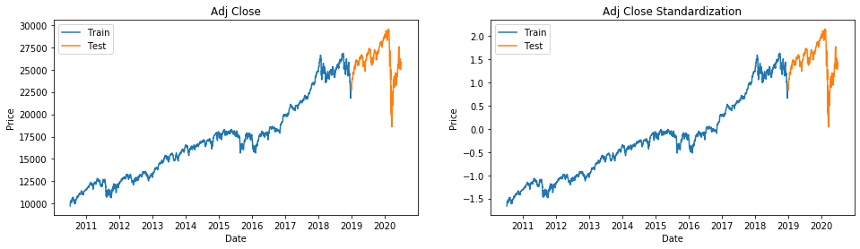

Create the input and response variables. Here the input is one day prior to the response.

```
x_train = train.to_numpy()[:-1].reshape(-1, 1)
y_train = train.to_numpy()[1:].flatten()

x_test = test.to_numpy()[:-1].reshape(-1, 1)
y_test = test.to_numpy()[1:].flatten()
```

Train the `MLPRegressor` from `sklearn`

```
from sklearn.neural_network import MLPRegressor

mlp_reg = MLPRegressor(random_state=100, max_iter=10000).fit(x_train, y_train)
```

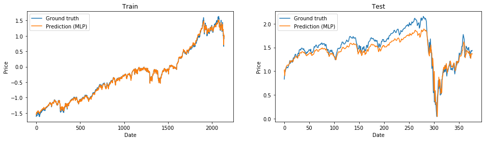

```
Mean squared error (train): 0.0014921846694880678
Mean squared error (test): 0.020510939299903174
```